# STAT 1341 - Sports Analytics

Final Project

Zach Palmer

## Environment Setup and Packages

```r
library(tidyverse)
library(dplyr)
library(knitr)
```

## Reading in Data

I will be simulating the regular season and playoffs for the 2005-2006 NHL season. I start by reading in the .csv files that contain all of the games throughout recorded league history and the corresponding team information. I then split the file of games into two subsets, one that contains all the games throughout history before the 05-06 season, and another that contains only the games during the 05-06 regular season.

```r
# read in the files and fix the unusual column names
scores = read.csv('data/nhl_scores.csv')
elos = read.csv('data/nhl_initial_elos.csv')
names(scores)[names(scores) == 'ï..id'] = 'id'
names(elos)[names(elos) == 'ï..team'] = 'team'

# filter for all games before the 05-06 season
prior_scores = scores %>%
  filter(season < 2005)

# filter for only those games that were part of the 05-06 regular season
current_scores = scores %>%
  filter(season == 2005 & game_type == 'r')

# read in the team statistics for 2005-06 season
team_stats = read.csv('data/team_season_stats.csv')
names(team_stats)[names(team_stats) == 'ï..id'] = 'id'
team_stats = team_stats %>%
  select(id, Team, AvAge, PTS, SRS, SOS, PP., PK., S, SA, S., SV.)
```

## Calculating the Preseason Elo Ratings

The following code segment calculates each NHL teams’ preseason Elo rating before the start of the 05-06 regular season. I also removed those teams within the “elos” data frame that did not participate in the 05-06 season.

```r
# from lecture 18
weight = 7.1
hfa = 51.63

# Iterate through all games in the sport's history
for(i in 1:nrow(prior_scores)) {
  # Find indices corresponding to home and away teams for current game
  home_index = which(elos$team == prior_scores$home_team[i])
  away_index = which(elos$team == prior_scores$away_team[i])

  # Find home and away team Elo ratings
  home_elo = elos$rating[home_index]
  away_elo = elos$rating[away_index]

  # Calculate home team win probability
  win_prob = 1 / (10 ^ ((away_elo - (home_elo + hfa * prior_scores$neutral[i]))/400) + 1)

  # Calculate actual margin of victory - must be positive
  score_diff = abs(prior_scores$home_score[i] - prior_scores$away_score[i])

  # Determine home team result
  if(prior_scores$home_score[i] > prior_scores$away_score[i]) {
    home_result = 1  # Home team wins
  } else if(prior_scores$home_score[i] < prior_scores$away_score[i]) {
    home_result = 0  # Home team loses
  } else {
    home_result = 0.5  # Tie
  }

  # Calculate amount each team's Elo rating is adjusted by
  home_elo_adjustment = weight * log(score_diff + 1) * (home_result - win_prob)

  # Adjust Elo ratings - add point to winner and subtract points from loser
  elos$rating[home_index] = elos$rating[home_index] + home_elo_adjustment
  elos$rating[away_index] = elos$rating[away_index] - home_elo_adjustment

  # Adjust Elo ratings at end of season to regress 1/3 of the way towards 1500
  if(i < nrow(prior_scores) && prior_scores$season[i + 1] > prior_scores$season[i]) {
    for(j in 1:nrow(elos)) {  # For each team
      if(prior_scores$season[i] >= elos$inaugural_season[j]) {  # Check if team existed
        # Move each team's Elo rating back towards 1500 by 1/3 of the difference
        elos$rating[j] = elos$rating[j] - (elos$rating[j] - 1500)/3
      }
    }

    # Identify all teams that existed at beginning of following season
    existing_teams = elos[which(elos$inaugural_season <= (prior_scores$season[i] + 1)),]

    # Calculate amount each team's Elo rating must be adjusted by to make mean 1500
    expansion_adjustment = -1 * (mean(existing_teams$rating) - 1500)

    # Perform expansion adjustment on teams that existed at beginning of following season
    for(j in 1:nrow(elos)) {  # For each team
      if((prior_scores$season[i] + 1) >= elos$inaugural_season[j]) {  # Check if team existed
        elos$rating[j] = elos$rating[j] + expansion_adjustment  # Update ratings if so
      }
    }
  }
}

elos = elos %>%
  filter(inaugural_season <= 2005) %>%
  select(-inaugural_season) %>%
  drop_na()
```

The divisions and conferences are up to date rather than correct at the time of the 2005-06 season so I will fix them here.

```r
# team column
teams = c("New Jersey Devils", "Philadelphia Flyers", "New York Rangers", "New York Islanders",
          "Pittsburgh Penguins", "Ottawa Senators", "Buffalo Sabres", "Montreal Canadiens",
          "Toronto Maple Leafs", "Boston Bruins", "Carolina Hurricanes", "Tampa Bay Lightning",
          "Winnipeg Jets", "Florida Panthers", "Washington Capitals", "Detroit Red Wings",
          "Nashville Predators", "Columbus Blue Jackets", "Chicago Blackhawks",
          "St. Louis Blues", "Calgary Flames", "Colorado Avalanche", "Edmonton Oilers",
          "Vancouver Canucks", "Minnesota Wild", "Dallas Stars", "San Jose Sharks",
          "Anaheim Ducks", "Los Angeles Kings", "Phoenix Coyotes")

# conference column
conference = c("eastern", "eastern", "eastern", "eastern", "eastern", "eastern",
                "eastern", "eastern", "eastern", "eastern", "eastern", "eastern",
                "eastern", "eastern", "eastern", "western", "western", "western",
                "western", "western", "western", "western", "western", "western",
                "western", "western", "western", "western", "western", "western")

# division column
division = c("atlantic", "atlantic", "atlantic", "atlantic", "atlantic",
             "northeast", "northeast", "northeast", "northeast", "northeast",
             "southeast", "southeast", "southeast", "southeast", "southeast",
             "central", "central", "central", "central", "central",
             "northwest", "northwest", "northwest", "northwest", "northwest",
             "pacific", "pacific", "pacific", "pacific", "pacific")

# points column
points = c(101, 101, 100, 78, 58,
           113, 110, 93, 90, 74,
           112, 92, 90, 85, 70,
           124, 106, 74, 65, 57,
           103, 95, 95, 92, 84,
           112, 99, 98, 89, 81)

# overall data frame
team_divisions = data.frame(teams, conference, division, points)

for (i in 1:nrow(elos)) {
  if (elos[i, "team"] %in% teams) {
    elos[i, "division"] = team_divisions[which(team_divisions$teams == elos[i, "team"]),
                                         "division"]
    elos[i, "conference"] = team_divisions[which(team_divisions$teams == elos[i, "team"]),
                                           "conference"]
    elos[i, "points"] = team_divisions[which(team_divisions$teams == elos[i, "team"]),
                                           "points"]
  }
}
```

## Simulating the Regular Season and Playoffs

Using the altered code from Homework 11, I ran 10000 iterations of a simulation of the 05-06 NHL regular season and playoffs

```r
# setup
set.seed(2005)
simulated_season = 2005
iterations = 10000

# Grab the Elo rating, conference, and division for the teams
team_info = elos

# Obtain list of unique conference names and unique division names
conferences = na.omit(unique(team_info$conference))
divisions = na.omit(unique(team_info$division))

# Grab list of regular season games for season being simulated
season_schedule = current_scores

# set up the team_info and summary data frames
team_info = team_info[which(team_info$conference != 'NA'),]
summary = data.frame(matrix(0, ncol = 6, nrow = nrow(team_info)))
colnames(summary) = c("team", "average_points", "playoffs", "div_titles",
                      "conf_champs", "championships")
summary$team = team_info$team

histories = data.frame(matrix(0, ncol = nrow(team_info), nrow = iterations))
colnames(histories) = team_info$team

# first team to dive deeper into
first_team = "Los Angeles Kings"

# Create data frame to store information for team specified above
first_results = data.frame(matrix(ncol = 8, nrow = 0))
colnames(first_results) = c("opponent", "pregame_elo", "win_probability", "result",
                           "team_score", "opponent_score", "elo_adjustment", "postgame_elo")

# second team to dive deeper into
second_team = "St. Louis Blues"

# Create data frame to store information for team specified above
second_results = data.frame(matrix(ncol = 8, nrow = 0))
colnames(second_results) = c("opponent", "pregame_elo", "win_probability", "result",
                           "team_score", "opponent_score", "elo_adjustment", "postgame_elo")

# third team to dive deeper into
third_team = "Carolina Hurricanes"

# Create data frame to store information for team specified above
third_results = data.frame(matrix(ncol = 8, nrow = 0))
colnames(third_results) = c("opponent", "pregame_elo", "win_probability", "result",
                           "team_score", "opponent_score", "elo_adjustment", "postgame_elo")

count = 0
for (i in 1:iterations) {
  season_stats = team_info[,which(colnames(team_info) != "inaugural_season")]
  season_stats$points = 0
  season_stats$rand = runif(nrow(team_info))

  for (j in 1:nrow(season_schedule)) {
    # Find indices corresponding to home and away teams for current game
    home_index = which(season_stats$team == season_schedule$home_team[j])
    away_index = which(season_stats$team == season_schedule$away_team[j])

    # Find home and away team Elo ratings
    home_elo = season_stats$rating[home_index]
    away_elo = season_stats$rating[away_index]

    # Calculate home team win and tie probabilities
    tie_prob = (1/(sqrt(4 * pi))) * exp(-((away_elo - (home_elo + hfa *
                season_schedule$neutral[j])) ^ 2/160000))
    win_prob = 1/(10 ^ ((away_elo -
              (home_elo + hfa * season_schedule$neutral[j]))/400) + 1) - 0.50 * tie_prob
    u = runif(1)

    if (u < win_prob) {  # Home team wins in regulation
      season_stats$points[home_index] = season_stats$points[home_index] + 2
    } else if (u < win_prob + 0.50 * tie_prob) {  # Home team wins in OT/shootout
      season_stats$points[home_index] = season_stats$points[home_index] + 2
      season_stats$points[away_index] = season_stats$points[away_index] + 1
    } else if (u > win_prob + tie_prob) {  # Away team wins in regulation
      season_stats$points[away_index] = season_stats$points[away_index] + 2
    } else { # Away team wins in OT/shootout
      season_stats$points[home_index] = season_stats$points[home_index] + 1
      season_stats$points[away_index] = season_stats$points[away_index] + 2
    }

    # Calculate actual margin of victory - must be positive
    score_diff = abs(season_schedule$home_score[j] - season_schedule$away_score[j])

    # Determine home team result
    if (season_schedule$home_score[j] > season_schedule$away_score[j]) {
      home_result = 1  # Home team wins
    } else if (season_schedule$home_score[j] < season_schedule$away_score[j]) {
      home_result = 0  # Home team loses
    } else {
      home_result = 0.5  # Tie
    }

    # Calculate amount each team's Elo rating is adjusted by
    home_elo_adjustment = weight * log(score_diff + 1) * (home_result - win_prob)

    # Adjust Elo ratings after game has been simulated to get team's new strength
    season_stats$rating[home_index] = season_stats$rating[home_index] + home_elo_adjustment
    season_stats$rating[away_index] = season_stats$rating[away_index] - home_elo_adjustment

    if (i == 5) {
      count = count + 1
      # Add game information to team result data frame if the first team specified played
      if(season_schedule$home_team[j] == first_team | season_schedule$away_team[j] == first_team) {
        if(season_schedule$home_team[j] == first_team) {  # If specified team was at home
          first_results[nrow(first_results) + 1,] =
            c(season_schedule$away_team[j], season_stats$rating[home_index] - home_elo_adjustment,
              win_prob, home_result, season_schedule$home_score[j], season_schedule$away_score[j],
              home_elo_adjustment, season_stats$rating[home_index])
        } else {  # If specified team was away
          first_results[nrow(first_results) + 1,] =
            c(season_schedule$home_team[j], season_stats$rating[away_index] + home_elo_adjustment,
              1 - win_prob, 1 - home_result, season_schedule$away_score[j],
              season_schedule$home_score[j], -1 * home_elo_adjustment,
              season_stats$rating[away_index])
        }
      }

      # Add game information to team result data frame if the second team specified played
      if(season_schedule$home_team[j] == second_team | season_schedule$away_team[j] == second_team) {
        if(season_schedule$home_team[j] == second_team) {  # If specified team was at home
          second_results[nrow(second_results) + 1,] =
            c(season_schedule$away_team[j], season_stats$rating[home_index] - home_elo_adjustment,
              win_prob, home_result, season_schedule$home_score[j], season_schedule$away_score[j],
              home_elo_adjustment, season_stats$rating[home_index])
        } else {  # If specified team was away
          second_results[nrow(second_results) + 1,] =
            c(season_schedule$home_team[j], season_stats$rating[away_index] + home_elo_adjustment,
              1 - win_prob, 1 - home_result, season_schedule$away_score[j],
              season_schedule$home_score[j], -1 * home_elo_adjustment,
              season_stats$rating[away_index])
        }
      }
```

```r
      # Add game information to team result data frame if the third team specified played
      if(season_schedule$home_team[j] == third_team | season_schedule$away_team[j] == third_team) {
        if(season_schedule$home_team[j] == third_team) {  # If specified team was at home
          third_results[nrow(third_results) + 1,] =
            c(season_schedule$away_team[j], season_stats$rating[home_index] - home_elo_adjustment,
              win_prob, home_result, season_schedule$home_score[j], season_schedule$away_score[j],
              home_elo_adjustment, season_stats$rating[home_index])
        } else {  # If specified team was away
          third_results[nrow(third_results) + 1,] =
            c(season_schedule$home_team[j], season_stats$rating[away_index] + home_elo_adjustment,
              1 - win_prob, 1 - home_result, season_schedule$away_score[j],
              season_schedule$home_score[j], -1 * home_elo_adjustment,
              season_stats$rating[away_index])
        }
      }
    }
  }

  summary$average_points = summary$average_points + season_stats$points

  division_winners = data.frame(matrix(ncol = 6, nrow = 0))
  colnames(division_winners) = c("team", "conference", "division", "rating", "points", "rand")

  non_division_winners = data.frame(matrix(ncol = 6, nrow = 0))
  colnames(non_division_winners) = c("team", "conference", "division", "rating", "points", "rand")

  num_wild_cards = 5
  wild_card_teams = data.frame(matrix(ncol = 6, nrow = 0))
  colnames(wild_card_teams) = c("team", "conference", "division", "rating", "points", "rand")

  for (div in divisions) {
    div_standings = season_stats[which(season_stats$division == div),]
    div_standings = div_standings[order(-div_standings$points, -div_standings$rand),]
    division_winners = rbind(division_winners, div_standings[1,])
    non_division_winners = rbind(non_division_winners, div_standings[2:nrow(div_standings),])
  }

  for (conf in conferences) {
    wc_standings = non_division_winners[which(non_division_winners$conference == conf),]
    wc_standings = wc_standings[order(-wc_standings$points, -wc_standings$rand),]
    wild_card_teams = rbind(wild_card_teams, wc_standings[1:num_wild_cards,])
  }

  division_winners = division_winners[order(division_winners$conference, -division_winners$points,
                                            -division_winners$rand),]

  wild_card_teams = wild_card_teams[order(wild_card_teams$conference, -wild_card_teams$points,
                                          -wild_card_teams$rand),]

  for (j in 1:nrow(division_winners)) {
    index = which(season_stats$team == division_winners$team[j])
    summary$playoffs[index] = summary$playoffs[index] + 1
    summary$div_titles[index] = summary$div_titles[index] + 1
  }

  for (team in wild_card_teams$team) {
    index = which(season_stats$team == team)
    summary$playoffs[index] = summary$playoffs[index] + 1
  }

  games_per_round = c(7, 7, 7, 7)

  playoff_bracket = data.frame(matrix(-Inf, ncol = 6, nrow = 16))
  colnames(playoff_bracket) = c("team", "conference", "division", "rating", "points", "rand")
  next_round = NULL

  #NHL
  playoff_bracket[1,] = division_winners[1,]
  playoff_bracket[2,] = division_winners[2,]
  playoff_bracket[3,] = division_winners[3,]
  playoff_bracket[4,] = wild_card_teams[1,]
  playoff_bracket[5,] = wild_card_teams[2,]
  playoff_bracket[6,] = wild_card_teams[3,]
  playoff_bracket[7,] = wild_card_teams[4,]
  playoff_bracket[8,] = wild_card_teams[5,]
  playoff_bracket[9,] = division_winners[4,]
  playoff_bracket[10,] = division_winners[5,]
  playoff_bracket[11,] = division_winners[6,]
  playoff_bracket[12,] = wild_card_teams[6,]
  playoff_bracket[13,] = wild_card_teams[7,]
  playoff_bracket[14,] = wild_card_teams[8,]
  playoff_bracket[15,] = wild_card_teams[9,]
  playoff_bracket[16,] = wild_card_teams[10,]

  playoff_bracket$seed = rep(1:8, 2)

  # Simulate every round in the playoffs until the championship game/round
  for (round in 1:(length(games_per_round) - 1)) {
    for (j in 1:2) {  # Divide 'playoff_bracket' into two halves, separated by conference
      for(k in 1:(nrow(playoff_bracket)/4)) {  # Match 1 seed with 8 seed, 2 seed with 7 seed, etc.
        high_seed_index = 0.5 * nrow(playoff_bracket) * j - (0.5 * nrow(playoff_bracket) - k)
        low_seed_index = 0.5 * nrow(playoff_bracket) * j - (k - 1)

        # Obtain Elo ratings for high and low seeds
        high_seed_elo = playoff_bracket$rating[high_seed_index]
        low_seed_elo = playoff_bracket$rating[low_seed_index]

        # Calculate win probability for each team when they play at home against their playoff opponent
        high_seed_home_win_prob = 1 / (10 ^ ((low_seed_elo - (high_seed_elo + hfa))/400) + 1)
        low_seed_home_win_prob = 1 / (10 ^ ((high_seed_elo - (low_seed_elo + hfa))/400) + 1)

        # Create array of win probabilities where high seed gets 1 more home game than low seed
        win_probs = c(rep(high_seed_home_win_prob, ceiling(games_per_round[round]/2)),
                      1 - rep(low_seed_home_win_prob, floor(games_per_round[round]/2)))

        # Generate random numbers for each game in the round
        u = runif(games_per_round[round])
        # Calculate proportion of games won by higher seed
        high_seed_wins = sum(u < win_probs)/games_per_round[round]

        if(high_seed_wins > 0.50) {  # If high seed won more than 50% of games in series
          # Advance high seed to next round
          next_round = rbind(next_round, playoff_bracket[high_seed_index,])
        } else{  # If low seed won more than 50% of games in series
          # Advance low seed to next round
          next_round = rbind(next_round, playoff_bracket[low_seed_index,])
        }
      }
    }

    playoff_bracket = next_round  # Reset playoff bracket to consist of all remaining teams

    # Reseed for next round
    playoff_bracket = playoff_bracket[order(playoff_bracket$conference, playoff_bracket$seed),]
    next_round = NULL  # Reset list of teams in subsequent round to an empty data frame
  }
```

```r
  # Stanley Cup Finals
  playoff_bracket = playoff_bracket[order(-playoff_bracket$points, -playoff_bracket$rand),]

  high_seed_elo = playoff_bracket$rating[1]
  low_seed_elo = playoff_bracket$rating[2]
  high_seed_home_win_prob = 1/(10 ^ ((low_seed_elo - (high_seed_elo + hfa))/400) + 1)
  low_seed_home_win_prob = 1/(10 ^ ((high_seed_elo - (low_seed_elo + hfa))/400) + 1)
  win_probs = c(rep(high_seed_home_win_prob, ceiling(games_per_round[length(games_per_round)]/2)),
                1 - rep(low_seed_home_win_prob, floor(games_per_round[length(games_per_round)]/2)))
  u = runif(games_per_round[4])
  high_seed_wins = sum(u < win_probs)/games_per_round[4]

  if (high_seed_wins > 0.50) {
    champion = playoff_bracket[1,]
  } else {
    champion = playoff_bracket[2,]
  }

  for(team in playoff_bracket$team) {
    index = which(season_stats$team == team)
    summary$conf_champs[index] = summary$conf_champs[index] + 1
  }

  index = which(season_stats$team == champion$team)
  summary$championships[index] = summary$championships[index] + 1
  histories[i,] = season_stats$points
}

summary$average_points = summary$average_points/iterations
```

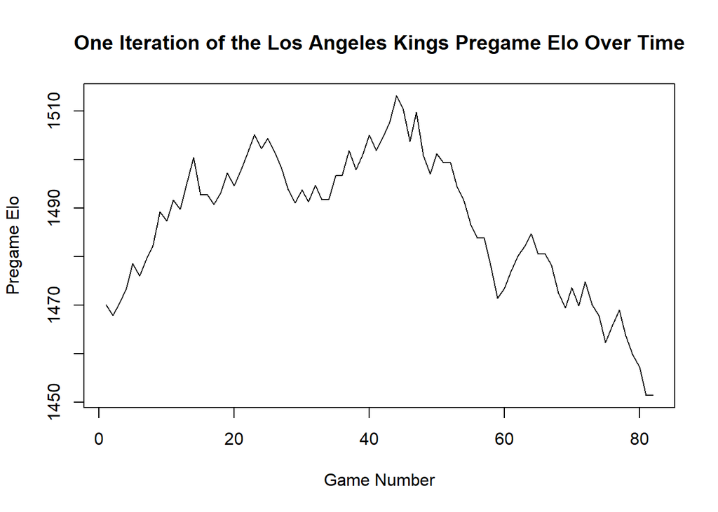

```r
plot(first_results$pregame_elo, xlab = "Game Number", ylab = "Pregame Elo",
     main = "One Iteration of the Los Angeles Kings Pregame Elo Over Time", type = "l")
```

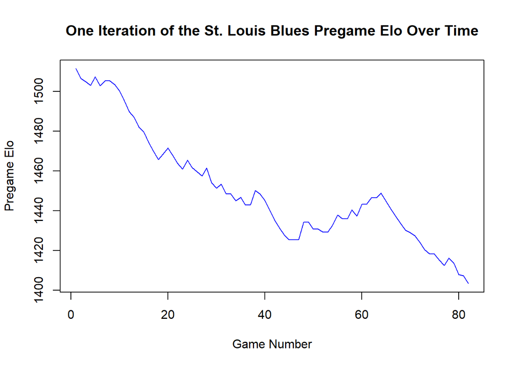

```r
plot(second_results$pregame_elo, xlab = "Game Number", ylab = "Pregame Elo",
     main = "One Iteration of the St. Louis Blues Pregame Elo Over Time", type = "l", col = "blue")
```

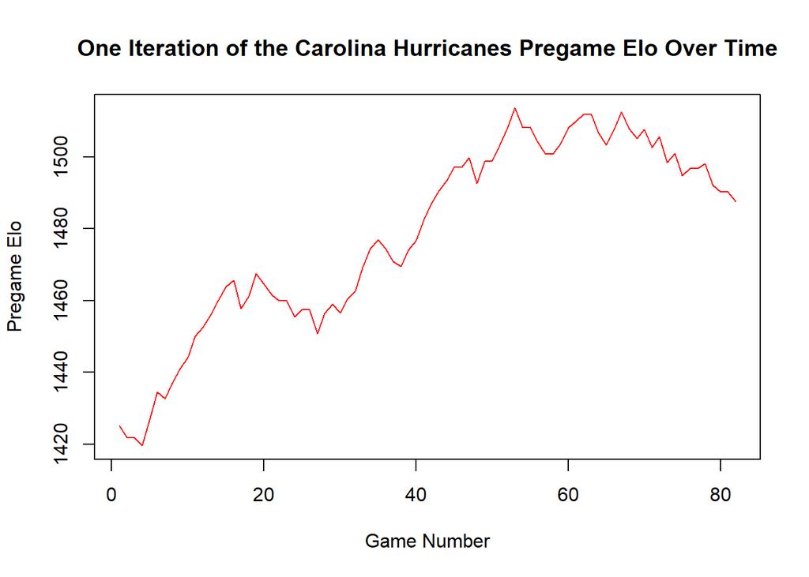

```r
plot(third_results$pregame_elo, xlab = "Game Number", ylab = "Pregame Elo",
     main = "One Iteration of the Carolina Hurricanes Pregame Elo Over Time", type = "l", col = "red")
```

## Elo Rating by Division

Swap the Winnipeg Jets to the Atlanta Thrashers

```r
# Switch the Winnipeg Jets to the Atlanta Thrashers
elos[which(elos$team == "Winnipeg Jets"), "team"] = "Atlanta Thrashers"
summary[which(summary$team == "Winnipeg Jets"), "team"] = "Atlanta Thrashers"
```

```r
atlantic = elos %>%
  filter(division == "atlantic")

northeast = elos %>%
  filter(division == "northeast")

southeast = elos %>%
  filter(division == "southeast")

central = elos %>%
  filter(division == "central")

northwest = elos %>%
  filter(division == "northwest")

pacific = elos %>%
  filter(division == "pacific")

kable(atlantic[, c(1, 4)], caption = "Atlantic Division Preseason Elos")
```

Atlantic Division Preseason Elos

| team | rating |
| --- | --- |
| New York Rangers | 1427.300 |
| Pittsburgh Penguins | 1371.019 |
| Philadelphia Flyers | 1569.541 |
| New York Islanders | 1514.499 |
| New Jersey Devils | 1564.851 |

```r
kable(northeast[, c(1, 4)], caption = "Northeast Division Preseason Elos")
```

Northeast Division Preseason Elos

| team | rating |
| --- | --- |
| Toronto Maple Leafs | 1559.750 |
| Montreal Canadiens | 1503.134 |
| Boston Bruins | 1523.926 |
| Buffalo Sabres | 1491.467 |
| Ottawa Senators | 1587.582 |

```r
kable(southeast[, c(1, 4)], caption = "Southeast Division Preseason Elos")
```

Southeast Division Preseason Elos

| team | rating |
| --- | --- |
| Tampa Bay Lightning | 1572.033 |
| Florida Panthers | 1420.979 |
| Washington Capitals | 1416.039 |
| Carolina Hurricanes | 1425.234 |
| Atlanta Thrashers | 1436.471 |

```r
kable(central[, c(1, 4)], caption = "Central Division Preseason Elos")
```

Central Division Preseason Elos

| team | rating |
| --- | --- |
| Detroit Red Wings | 1598.140 |
| Columbus Blue Jackets | 1413.183 |
| Chicago Blackhawks | 1403.457 |
| St. Louis Blues | 1511.479 |
| Nashville Predators | 1493.094 |

```r
kable(northwest[, c(1, 4)], caption = "Northwest Division Preseason Elos")
```

Northwest Division Preseason Elos

| team | rating |
| --- | --- |
| Colorado Avalanche | 1562.503 |
| Minnesota Wild | 1507.042 |
| Vancouver Canucks | 1559.794 |
| Calgary Flames | 1544.203 |
| Edmonton Oilers | 1527.284 |

```r
kable(pacific[, c(1, 4)], caption = "Pacific Division Preseason Elos")
```

Pacific Division Preseason Elos

[output not shown]

## Comparison of Actual and Simulated Points

```r
atlantic_summary = summary %>%
  inner_join(elos) %>%
  filter(division == "atlantic") %>%
  mutate(residual = points - average_points) %>%
  select(team, average_points, points, residual, rating)
northeast_summary = summary %>%
  inner_join(elos) %>%
  filter(division == "northeast") %>%
  mutate(residual = points - average_points) %>%
  select(team, average_points, points, residual, rating)
southeast_summary = summary %>%
  inner_join(elos) %>%
  filter(division == "southeast") %>%
  mutate(residual = points - average_points) %>%
  select(team, average_points, points, residual, rating)
central_summary = summary %>%
  inner_join(elos) %>%
  filter(division == "central") %>%
  mutate(residual = points - average_points) %>%
  select(team, average_points, points, residual, rating)
northwest_summary = summary %>%
  inner_join(elos) %>%
  filter(division == "northwest") %>%
  mutate(residual = points - average_points) %>%
  select(team, average_points, points, residual, rating)
pacific_summary = summary %>%
  inner_join(elos) %>%
  filter(division == "pacific") %>%
  mutate(residual = points - average_points) %>%
  select(team, average_points, points, residual, rating)
kable(atlantic_summary, caption = "Atlantic Division Simulation Results",
      format = "latex", booktabs = TRUE, longtable = FALSE)
```

```r
kable(northeast_summary, caption = "Northeast Division Simulation Results",
      format = "latex", booktabs = TRUE, longtable = FALSE)
```

```r
kable(southeast_summary, caption = "Southeast Division Simulation Results",
      format = "latex", booktabs = TRUE, longtable = FALSE)
```

```r
kable(central_summary, caption = "Central Division Simulation Results",
      format = "latex", booktabs = TRUE, longtable = FALSE)
```

```r
kable(northwest_summary, caption = "Northwest Division Simulation Results",
      format = "latex", booktabs = TRUE, longtable = FALSE)
```

```r
kable(pacific_summary, caption = "Pacific Division Simulation Results",
      format = "latex", booktabs = TRUE, longtable = FALSE)
```

## Simulated Playoff Results

```r
atlantic_summary = summary %>%
  inner_join(elos) %>%
  filter(division == "atlantic") %>%
  select(-average_points, -points, -conference, -division)
northeast_summary = summary %>%
  inner_join(elos) %>%
  filter(division == "northeast") %>%
  select(-average_points, -points, -conference, -division)
southeast_summary = summary %>%
  inner_join(elos) %>%
  filter(division == "southeast") %>%
  select(-average_points, -points, -conference, -division)
central_summary = summary %>%
  inner_join(elos) %>%
  filter(division == "central") %>%
  select(-average_points, -points, -conference, -division)
northwest_summary = summary %>%
  inner_join(elos) %>%
  filter(division == "northwest") %>%
  select(-average_points, -points, -conference, -division)
pacific_summary = summary %>%
  inner_join(elos) %>%
  filter(division == "pacific") %>%
  select(-average_points, -points, -conference, -division)
kable(atlantic_summary, caption = "Atlantic Division Simulation Results",
      format = "latex", booktabs = TRUE, longtable = FALSE)
```

```r
kable(northeast_summary, caption = "Northeast Division Simulation Results",
      format = "latex", booktabs = TRUE, longtable = FALSE)
```

```r
kable(southeast_summary, caption = "Southeast Division Simulation Results",
      format = "latex", booktabs = TRUE, longtable = FALSE)
```

```r
kable(central_summary, caption = "Central Division Simulation Results",
      format = "latex", booktabs = TRUE, longtable = FALSE)
```

```r
kable(northwest_summary, caption = "Northwest Division Simulation Results",
      format = "latex", booktabs = TRUE, longtable = FALSE)
```

```r
kable(pacific_summary, caption = "Pacific Division Simulation Results",
      format = "latex", booktabs = TRUE, longtable = FALSE)
```

## Comparison Graphics

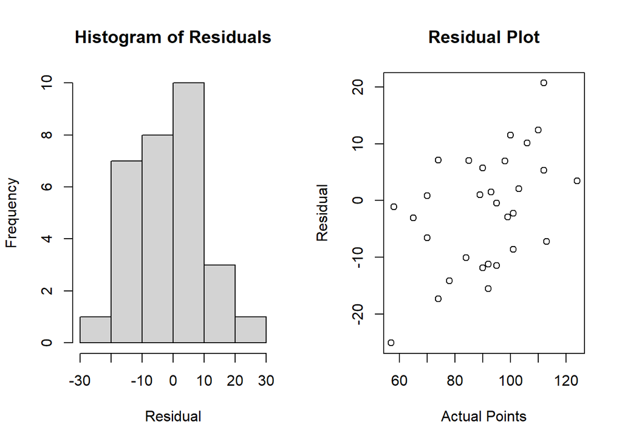

```r
summary = summary %>%
  mutate(actual_pts = elos$points,
         pts_diff = actual_pts - average_points)

par(mfrow = c(1, 2))
hist(summary$pts_diff, xlab = "Residual", main = "Histogram of Residuals")
plot(summary$actual_pts, summary$pts_diff, xlab = "Actual Points", ylab = "Residual",
     main = "Residual Plot")
```

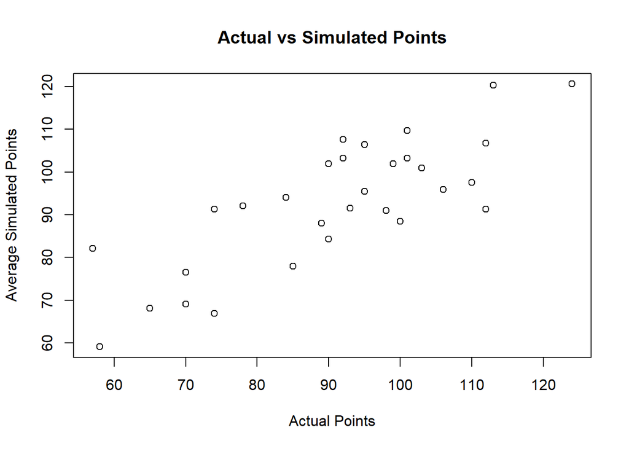

```r
plot(summary$actual_pts, summary$average_points, xlab = "Actual Points",
     ylab = "Average Simulated Points", main = "Actual vs Simulated Points")
```

```r
cor(summary$actual_pts, summary$average_points)
```

```
## [1] 0.8018191
```

## Actual Team Season Statistics

```r
team_stats = team_stats %>%
  mutate(S.SA = S/(S + SA),
         PDO = (SV. * 100) + S.) %>%
  select(id, Team, PTS, PP., PK., S.SA, PDO)
```

```r
league_avg = team_stats %>%
  summarise(avg.pts = sum(PTS)/n(),
            avg.PP = sum(PP.)/n(),
            avg.PK = sum(PK.)/n(),
            avg.S.SA = sum(S.SA)/n(),
            avg.PDO = sum(PDO)/n())

kable(league_avg, caption = "Actual League Average Statistics for the Regular Season",
      format = "latex", booktabs = TRUE, longtable = FALSE)
```

```r
comparison_stats = team_stats %>%
  filter(Team == first_team | Team == second_team | Team == third_team) %>%
  mutate(diff.PP = PP. - league_avg$avg.PP,
         diff.PK = PK. - league_avg$avg.PK,
         diff.S.SA = S.SA - league_avg$avg.S.SA,
         diff.PDO = PDO - league_avg$avg.PDO) %>%
  select(-id, -PTS)

comparison_stats
```

| Team | PP. | PK. | S.SA | PDO | diff.PP | diff.PK | diff.S.SA | diff.PDO |
| --- | --- | --- | --- | --- | --- | --- | --- | --- |
| Carolina Hurricanes | 17.89 | 81.80 | 0.5055446 | 100.9 | 0.248 | -0.5526667 | 0.005201381 | 0.9 |
| Los Angeles Kings | 14.23 | 78.73 | 0.4933031 | 99.3 | -3.412 | -3.6226667 | -0.007040062 | -0.7 |
| St. Louis Blues | 14.65 | 82.21 | 0.4819401 | 97.0 | -2.992 | -0.1426667 | -0.018403029 | -3.0 |

```r
kable(comparison_stats[1, ], caption = "Season Statistics for the Carolina Hurricanes",
      format = "latex", booktabs = TRUE, longtable = FALSE)
```

```r
kable(comparison_stats[2, ], caption = "Season Statistics for the Los Angeles Kings",
      format = "latex", booktabs = TRUE, longtable = FALSE)
```

```r
kable(comparison_stats[3, ], caption = "Season Statistics for the St. Louis Blues",
      format = "latex", booktabs = TRUE, longtable = FALSE)
```

## Simulation vs. Statistics Graphics

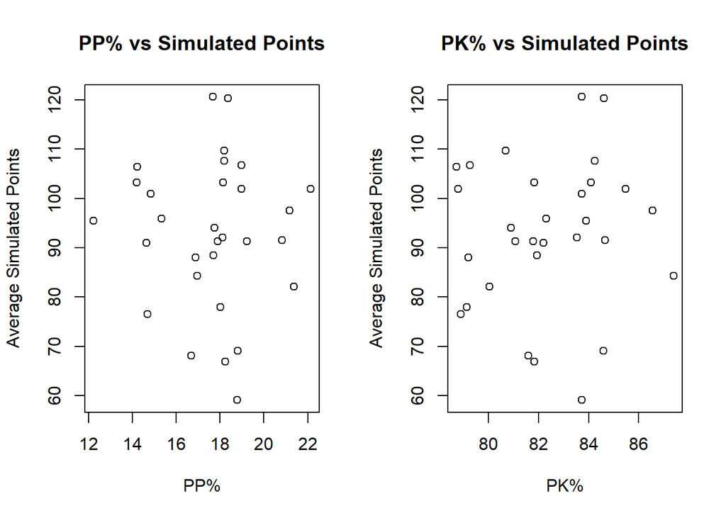

```r
par(mfrow = c(1, 2))

plot(team_stats$PP., summary$average_points, xlab = "PP%",
     ylab = "Average Simulated Points", main = "PP% vs Simulated Points")


plot(team_stats$PK., summary$average_points, xlab = "PK%",
     ylab = "Average Simulated Points", main = "PK% vs Simulated Points")
```

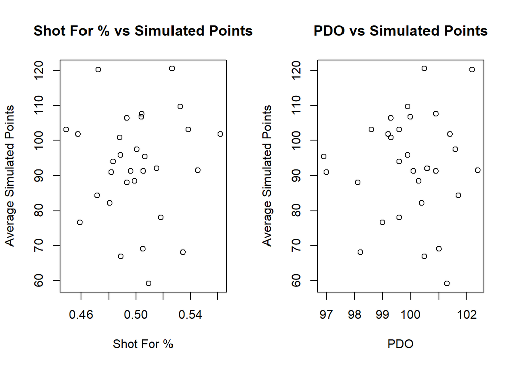

```r
plot(team_stats$S.SA, summary$average_points, xlab = "Shot For %",
     ylab = "Average Simulated Points", main = "Shot For % vs Simulated Points")

plot(team_stats$PDO, summary$average_points, xlab = "PDO",
     ylab = "Average Simulated Points", main = "PDO vs Simulated Points")
```

```r
cor(team_stats$PP., summary$average_points)
```

```
## [1] -0.04339668
```

```r
cor(team_stats$PK., summary$average_points)
```

```
## [1] 0.08122941
```

```r
cor(team_stats$S.SA, summary$average_points)
```

```
## [1] 0.02585755
```

```r
cor(team_stats$PDO, summary$average_points)
```

```
## [1] 0.05311544
```